# LUẬT KẾT HỢP (Association Rules) với FP-Growth

## Tìm mối liên hệ 'nếu-thì' giữa các yếu tố tai nạn

**Mục tiêu**: Áp dụng thuật toán FP-Growth để khám phá các luật kết hợp (association rules) giữa các yếu tố gây tai nạn giao thông, nhằm tìm ra những mối liên hệ "nếu-thì" có ý nghĩa.

**Phương pháp**:

- Thuật toán FP-Growth để tìm tập phổ biến (frequent itemsets)
- Tạo luật kết hợp với các chỉ số: Support, Confidence, Lift
- Lọc các luật có ý nghĩa thực tiễn

## 1. Import thư viện cần thiết

```python
# Import thư viện cơ bản
import pandas as pd
import numpy as np
import warnings
warnings.filterwarnings('ignore')

# Import thư viện cho FP-Growth và Association Rules
from mlxtend.preprocessing import TransactionEncoder
from mlxtend.frequent_patterns import fpgrowth, association_rules

# Import thư viện cho visualization
import matplotlib.pyplot as plt
import seaborn as sns
import networkx as nx

# Import thư viện bổ sung
from pathlib import Path

# Cấu hình hiển thị
plt.rcParams['figure.figsize'] = (12, 8)
plt.rcParams['font.size'] = 10
pd.set_option('display.max_columns', None)
pd.set_option('display.max_rows', 100)
pd.set_option('display.width', None)

print("✓ Đã import thành công tất cả thư viện!")
```

```
✓ Đã import thành công tất cả thư viện!
```

## 2. Tải và chuẩn bị dữ liệu

```python
# Đường dẫn file dữ liệu đã tiền xử lý
data_path = Path('../ssis_project/preprocess/US_Accidents_March23-preprocessed.csv')

# Đọc dữ liệu với tối ưu hóa dtype
print("Đang tải dữ liệu đã tiền xử lý...")
dtype_dict = {
    'SEVERITY': 'int8',
    'LATITUDE': 'float32',
    'LONGITUDE': 'float32',
    'TEMPERATURE': 'float32',
    'VISIBILITY': 'float32',
    'HOUR': 'int8',
    'IS_WEEKEND': 'bool',
    'AMENITY': 'bool',
    'BUMP': 'bool',
    'CROSSING': 'bool',
    'GIVE_WAY': 'bool',
    'JUNCTION': 'bool',
    'NO_EXIT': 'bool',
    'RAILWAY': 'bool',
    'ROUNDABOUT': 'bool',
    'STATION': 'bool',
    'STOP': 'bool',
    'TRAFFIC_CALMING': 'bool',
    'TRAFFIC_SIGNAL': 'bool',
    'TURNING_LOOP': 'bool'
}

# Chọn các cột cần thiết
cols_to_use = [
    'HOUR', 'IS_WEEKEND', 'TEMPERATURE', 'VISIBILITY',
    'AMENITY', 'BUMP', 'CROSSING', 'GIVE_WAY', 'JUNCTION',
    'NO_EXIT', 'RAILWAY', 'ROUNDABOUT', 'STATION', 'STOP',
    'TRAFFIC_CALMING', 'TRAFFIC_SIGNAL', 'TURNING_LOOP'
]

df = pd.read_csv(data_path, usecols=cols_to_use, dtype=dtype_dict, low_memory=False)

print(f"✓ Đã tải {len(df):,} bản ghi")
print(f"✓ Kích thước dữ liệu: {df.memory_usage(deep=True).sum() / 1024**2:.2f} MB")
print(f"\nThông tin dữ liệu:")
df.info()
```

```
Đang tải dữ liệu đã tiền xử lý...
✓ Đã tải 5,539,531 bản ghi
✓ Kích thước dữ liệu: 121.51 MB

Thông tin dữ liệu:
<class 'pandas.core.frame.DataFrame'>
RangeIndex: 5539531 entries, 0 to 5539530
Data columns (total 17 columns):
 #   Column           Dtype
---  ------           -----
 0   HOUR             int8
 1   IS_WEEKEND       bool
 2   TEMPERATURE      float32
 3   VISIBILITY       float32
 4   AMENITY          bool
 5   BUMP             bool
 6   CROSSING         bool
 7   GIVE_WAY         bool
 8   JUNCTION         bool
 9   NO_EXIT          bool
 10  RAILWAY          bool
 11  ROUNDABOUT       bool
 12  STATION          bool
 13  STOP             bool
 14  TRAFFIC_CALMING  bool
 15  TRAFFIC_SIGNAL   bool
 16  TURNING_LOOP     bool
dtypes: bool(14), float32(2), int8(1)
memory usage: 121.5 MB
```

## 3. Xử lý dữ liệu thiếu và lấy mẫu

```python
# Kiểm tra dữ liệu thiếu
print("Dữ liệu thiếu trước khi xử lý:")
print(df.isnull().sum())

# Xử lý dữ liệu thiếu
# Loại bỏ các dòng có giá trị thiếu ở TEMPERATURE và VISIBILITY
df_clean = df.dropna(subset=['TEMPERATURE', 'VISIBILITY']).copy()

# Fill False cho các cột boolean (infrastructure features)
infrastructure_cols = [
    'AMENITY', 'BUMP', 'CROSSING', 'GIVE_WAY', 'JUNCTION',
    'NO_EXIT', 'RAILWAY', 'ROUNDABOUT', 'STATION', 'STOP',
    'TRAFFIC_CALMING', 'TRAFFIC_SIGNAL', 'TURNING_LOOP'
]

for col in infrastructure_cols:
    df_clean[col] = df_clean[col].fillna(False)

print(f"\n✓ Sau khi xử lý: {len(df_clean):,} bản ghi")
print(f"✓ Đã loại bỏ {len(df) - len(df_clean):,} bản ghi ({(len(df) - len(df_clean))/len(df)*100:.2f}%)")

# Lấy mẫu ngẫu nhiên để tối ưu hóa tốc độ xử lý
# FP-Growth hoạt động tốt với dataset lớn, nhưng để demo ta lấy 100k mẫu
sample_size = 100000
if len(df_clean) > sample_size:
    df_sample = df_clean.sample(n=sample_size, random_state=42)
    print(f"\n✓ Đã lấy mẫu ngẫu nhiên {sample_size:,} bản ghi")
else:
    df_sample = df_clean.copy()
    print(f"\n✓ Sử dụng toàn bộ {len(df_sample):,} bản ghi")

print(f"\nKích thước dữ liệu làm việc: {df_sample.memory_usage(deep=True).sum() / 1024**2:.2f} MB")
```

```
Dữ liệu thiếu trước khi xử lý:
HOUR                    0
IS_WEEKEND              0
TEMPERATURE        118569
VISIBILITY         125036
AMENITY                 0
BUMP                    0
CROSSING                0
GIVE_WAY                0
JUNCTION                0
NO_EXIT                 0
RAILWAY                 0
ROUNDABOUT              0
STATION                 0
STOP                    0
TRAFFIC_CALMING         0
TRAFFIC_SIGNAL          0
TURNING_LOOP            0
dtype: int64

✓ Sau khi xử lý: 5,395,775 bản ghi
✓ Đã loại bỏ 143,756 bản ghi (2.60%)

✓ Đã lấy mẫu ngẫu nhiên 100,000 bản ghi

Kích thước dữ liệu làm việc: 2.96 MB
```

## 4. Rời rạc hóa các đặc trưng liên tục

Chuyển đổi các đặc trưng liên tục và thời gian thành các category để phù hợp với Association Rules:

- **Temperature**: 3 bins (COLD < 50°F, NORMAL 50-80°F, HOT > 80°F)
- **Visibility**: 3 bins (LOW < 2mi, MEDIUM 2-5mi, HIGH > 5mi)
- **Hour**: 4 thời đoạn (NIGHT 0-6h, MORNING 6-12h, AFTERNOON 12-18h, EVENING 18-24h)
- **Is_Weekend**: Boolean (Thứ 7 hoặc Chủ nhật)

```python
# Dataset đã có HOUR và IS_WEEKEND, không cần trích xuất từ Start_Time
# Dữ liệu đã được tiền xử lý sẵn

# 1. Rời rạc hóa TEMPERATURE
# Phân tích phân bố nhiệt độ
print("Phân bố TEMPERATURE:")
print(df_sample['TEMPERATURE'].describe())

# Chia thành 3 bins: COLD, NORMAL, HOT
df_sample['TEMP_COLD'] = (df_sample['TEMPERATURE'] < 50).astype(int)
df_sample['TEMP_NORMAL'] = ((df_sample['TEMPERATURE'] >= 50) & (df_sample['TEMPERATURE'] <= 80)).astype(int)
df_sample['TEMP_HOT'] = (df_sample['TEMPERATURE'] > 80).astype(int)

print(f"\nTEMP_COLD (<50°F): {df_sample['TEMP_COLD'].sum():,} ({df_sample['TEMP_COLD'].mean()*100:.1f}%)")
print(f"TEMP_NORMAL (50-80°F): {df_sample['TEMP_NORMAL'].sum():,} ({df_sample['TEMP_NORMAL'].mean()*100:.1f}%)")
print(f"TEMP_HOT (>80°F): {df_sample['TEMP_HOT'].sum():,} ({df_sample['TEMP_HOT'].mean()*100:.1f}%)")

# 2. Rời rạc hóa VISIBILITY
print("\n\nPhân bố VISIBILITY:")
print(df_sample['VISIBILITY'].describe())

# Chia thành 3 bins: LOW, MEDIUM, HIGH
df_sample['VIS_LOW'] = (df_sample['VISIBILITY'] < 2).astype(int)
df_sample['VIS_MEDIUM'] = ((df_sample['VISIBILITY'] >= 2) & (df_sample['VISIBILITY'] <= 5)).astype(int)
df_sample['VIS_HIGH'] = (df_sample['VISIBILITY'] > 5).astype(int)

print(f"\nVIS_LOW (<2mi): {df_sample['VIS_LOW'].sum():,} ({df_sample['VIS_LOW'].mean()*100:.1f}%)")
print(f"VIS_MEDIUM (2-5mi): {df_sample['VIS_MEDIUM'].sum():,} ({df_sample['VIS_MEDIUM'].mean()*100:.1f}%)")
print(f"VIS_HIGH (>5mi): {df_sample['VIS_HIGH'].sum():,} ({df_sample['VIS_HIGH'].mean()*100:.1f}%)")

# 3. Rời rạc hóa HOUR thành 4 thời đoạn
df_sample['HOUR_NIGHT'] = ((df_sample['HOUR'] >= 0) & (df_sample['HOUR'] < 6)).astype(int)
df_sample['HOUR_MORNING'] = ((df_sample['HOUR'] >= 6) & (df_sample['HOUR'] < 12)).astype(int)
df_sample['HOUR_AFTERNOON'] = ((df_sample['HOUR'] >= 12) & (df_sample['HOUR'] < 18)).astype(int)
df_sample['HOUR_EVENING'] = ((df_sample['HOUR'] >= 18) & (df_sample['HOUR'] < 24)).astype(int)

print("\n\nPhân bố theo thời đoạn trong ngày:")
print(f"HOUR_NIGHT (0-6h): {df_sample['HOUR_NIGHT'].sum():,} ({df_sample['HOUR_NIGHT'].mean()*100:.1f}%)")
print(f"HOUR_MORNING (6-12h): {df_sample['HOUR_MORNING'].sum():,} ({df_sample['HOUR_MORNING'].mean()*100:.1f}%)")
print(f"HOUR_AFTERNOON (12-18h): {df_sample['HOUR_AFTERNOON'].sum():,} ({df_sample['HOUR_AFTERNOON'].mean()*100:.1f}%)")
print(f"HOUR_EVENING (18-24h): {df_sample['HOUR_EVENING'].sum():,} ({df_sample['HOUR_EVENING'].mean()*100:.1f}%)")

# 4. IS_WEEKEND đã có sẵn trong dataset, chuyển sang int để thống nhất
df_sample['IS_WEEKEND'] = df_sample['IS_WEEKEND'].astype(int)

print("\n\nPhân bố cuối tuần:")
print(f"IS_WEEKEND: {df_sample['IS_WEEKEND'].sum():,} ({df_sample['IS_WEEKEND'].mean()*100:.1f}%)")

print("\n✓ Hoàn thành rời rạc hóa các đặc trưng!")
```

[output not shown]

## 5. Chuẩn bị dữ liệu cho FP-Growth (Binary Matrix)

Chuyển đổi dữ liệu sang dạng One-Hot Encoding (Binary Matrix) cho các thuật toán Association Rules.

```python
# Chọn tất cả các features đã được binary hóa
binary_features = [
    # 13 infrastructure features (sử dụng tên UPPERCASE từ dataset)
    'AMENITY', 'BUMP', 'CROSSING', 'GIVE_WAY', 'JUNCTION',
    'NO_EXIT', 'RAILWAY', 'ROUNDABOUT', 'STATION', 'STOP',
    'TRAFFIC_CALMING', 'TRAFFIC_SIGNAL', 'TURNING_LOOP',
    # Temperature bins
    'TEMP_COLD', 'TEMP_NORMAL', 'TEMP_HOT',
    # Visibility bins
    'VIS_LOW', 'VIS_MEDIUM', 'VIS_HIGH',
    # Hour periods
    'HOUR_NIGHT', 'HOUR_MORNING', 'HOUR_AFTERNOON', 'HOUR_EVENING',
    # Weekend
    'IS_WEEKEND'
]

# Tạo binary matrix
df_binary = df_sample[binary_features].copy()

# Đổi tên các infrastructure features cho dễ hiểu trong kết quả
rename_dict = {
    'AMENITY': 'INFRA_Amenity',
    'BUMP': 'INFRA_Bump',
    'CROSSING': 'INFRA_Crossing',
    'GIVE_WAY': 'INFRA_GiveWay',
    'JUNCTION': 'INFRA_Junction',
    'NO_EXIT': 'INFRA_NoExit',
    'RAILWAY': 'INFRA_Railway',
    'ROUNDABOUT': 'INFRA_Roundabout',
    'STATION': 'INFRA_Station',
    'STOP': 'INFRA_Stop',
    'TRAFFIC_CALMING': 'INFRA_TrafficCalming',
    'TRAFFIC_SIGNAL': 'INFRA_TrafficSignal',
    'TURNING_LOOP': 'INFRA_TurningLoop'
}

df_binary = df_binary.rename(columns=rename_dict)

# Chuyển đổi sang boolean
df_binary = df_binary.astype(bool)

print(f"✓ Ma trận binary: {df_binary.shape}")
print(f"✓ Số lượng features: {len(df_binary.columns)}")
print(f"\nDanh sách các features:")
for i, col in enumerate(df_binary.columns, 1):
    freq = df_binary[col].sum()
    pct = (freq / len(df_binary)) * 100
    print(f"  {i:2d}. {col:25s}: {freq:6,} ({pct:5.2f}%)")
```

```
✓ Ma trận binary: (100000, 24)
✓ Số lượng features: 24

Danh sách các features:
   1. INFRA_Amenity            :  1,240 ( 1.24%)
   2. INFRA_Bump               :     50 ( 0.05%)
   3. INFRA_Crossing           : 11,557 (11.56%)
   4. INFRA_GiveWay            :    477 ( 0.48%)
   5. INFRA_Junction           :  6,970 ( 6.97%)
   6. INFRA_NoExit             :    258 ( 0.26%)
   7. INFRA_Railway            :    859 ( 0.86%)
   8. INFRA_Roundabout         :      3 ( 0.00%)
   9. INFRA_Station            :  2,582 ( 2.58%)
  10. INFRA_Stop               :  2,796 ( 2.80%)
  11. INFRA_TrafficCalming     :    103 ( 0.10%)
  12. INFRA_TrafficSignal      : 15,050 (15.05%)
  13. INFRA_TurningLoop        :      0 ( 0.00%)
  14. TEMP_COLD                : 26,836 (26.84%)
  15. TEMP_NORMAL              : 57,328 (57.33%)
  16. TEMP_HOT                 : 15,836 (15.84%)
  17. VIS_LOW                  :  3,417 ( 3.42%)
  18. VIS_MEDIUM               :  7,187 ( 7.19%)
  19. VIS_HIGH                 : 89,396 (89.40%)
  20. HOUR_NIGHT               : 10,673 (10.67%)
  21. HOUR_MORNING             : 34,814 (34.81%)
  22. HOUR_AFTERNOON           : 36,251 (36.25%)
  23. HOUR_EVENING             : 18,262 (18.26%)
  24. IS_WEEKEND               : 15,913 (15.91%)
```

## 6. Áp dụng thuật toán FP-Growth

**FP-Growth** (Frequent Pattern Growth) là thuật toán hiệu quả để tìm tập phổ biến (frequent itemsets) mà không cần tạo candidate sets như Apriori.

**Tham số**:

- `min_support = 0.005` (0.5%): Một tập item xuất hiện ít nhất 0.5% số giao dịch mới được coi là phổ biến

```python
import time

# Tham số cho FP-Growth
min_support = 0.005  # 0.5% - tập item xuất hiện ít nhất 0.5% số giao dịch

print(f"Đang chạy FP-Growth với min_support = {min_support} ({min_support*100}%)...")
print(f"Ngưỡng tối thiểu: {int(min_support * len(df_binary)):,} giao dịch\n")

start_time = time.time()

# Áp dụng FP-Growth
frequent_itemsets = fpgrowth(df_binary, min_support=min_support, use_colnames=True)

end_time = time.time()

print(f"✓ Hoàn thành trong {end_time - start_time:.2f} giây")
print(f"✓ Tìm thấy {len(frequent_itemsets):,} tập phổ biến (frequent itemsets)")

# Thêm cột length (số lượng items trong mỗi itemset)
frequent_itemsets['length'] = frequent_itemsets['itemsets'].apply(lambda x: len(x))

# Thống kê theo độ dài
print("\nPhân bố theo độ dài itemsets:")
length_counts = frequent_itemsets['length'].value_counts().sort_index()
for length, count in length_counts.items():
    print(f"  {length}-itemsets: {count:,}")

# Hiển thị top 20 frequent itemsets có support cao nhất
print("\n" + "="*80)
print("TOP 20 FREQUENT ITEMSETS CÓ SUPPORT CAO NHẤT:")
print("="*80)
top_itemsets = frequent_itemsets.nlargest(20, 'support')
for idx, row in top_itemsets.iterrows():
    items = ', '.join(sorted(row['itemsets']))
    print(f"Support: {row['support']:.4f} ({row['support']*100:5.2f}%) | Items: {{{items}}}")
```

```
Đang chạy FP-Growth với min_support = 0.005 (0.5%)...
Ngưỡng tối thiểu: 500 giao dịch

✓ Hoàn thành trong 35.79 giây
✓ Tìm thấy 286 tập phổ biến (frequent itemsets)

Phân bố theo độ dài itemsets:
  1-itemsets: 18
  2-itemsets: 91
  3-itemsets: 119
  4-itemsets: 53
  5-itemsets: 5

================================================================================
TOP 20 FREQUENT ITEMSETS CÓ SUPPORT CAO NHẤT:
================================================================================
Support: 0.8940 (89.40%) | Items: {VIS_HIGH}
Support: 0.5733 (57.33%) | Items: {TEMP_NORMAL}
Support: 0.5194 (51.94%) | Items: {TEMP_NORMAL, VIS_HIGH}
Support: 0.3625 (36.25%) | Items: {HOUR_AFTERNOON}
Support: 0.3481 (34.81%) | Items: {HOUR_MORNING}
Support: 0.3352 (33.52%) | Items: {HOUR_AFTERNOON, VIS_HIGH}
Support: 0.2999 (29.99%) | Items: {HOUR_MORNING, VIS_HIGH}
Support: 0.2684 (26.84%) | Items: {TEMP_COLD}
Support: 0.2180 (21.80%) | Items: {TEMP_COLD, VIS_HIGH}
Support: 0.2051 (20.51%) | Items: {HOUR_MORNING, TEMP_NORMAL}
Support: 0.1995 (19.95%) | Items: {HOUR_AFTERNOON, TEMP_NORMAL}
Support: 0.1860 (18.60%) | Items: {HOUR_AFTERNOON, TEMP_NORMAL, VIS_HIGH}
Support: 0.1826 (18.26%) | Items: {HOUR_EVENING}
Support: 0.1790 (17.90%) | Items: {HOUR_MORNING, TEMP_NORMAL, VIS_HIGH}
Support: 0.1668 (16.68%) | Items: {HOUR_EVENING, VIS_HIGH}
Support: 0.1591 (15.91%) | Items: {IS_WEEKEND}
Support: 0.1584 (15.84%) | Items: {TEMP_HOT}
Support: 0.1566 (15.66%) | Items: {TEMP_HOT, VIS_HIGH}
Support: 0.1505 (15.05%) | Items: {INFRA_TrafficSignal}
Support: 0.1423 (14.23%) | Items: {IS_WEEKEND, VIS_HIGH}
```

## 7. Tạo luật kết hợp (Association Rules)

Từ các frequent itemsets, tạo ra các luật kết hợp dạng "Nếu A → Thì B" với các chỉ số:

- **Support**: Tần suất xuất hiện của cả A và B
- **Confidence**: Xác suất B xuất hiện khi A xuất hiện (P(B|A))
- **Lift**: Mức độ tăng cường của luật so với ngẫu nhiên (Lift > 1: có tương quan dương)

**Tham số**:

- `metric = "confidence"`: Sắp xếp theo confidence
- `min_threshold = 0.4`: Confidence tối thiểu 40%
- `lift > 1.5`: Chỉ giữ các luật có lift > 1.5 (tương quan mạnh)

```python
# Tham số cho Association Rules
min_confidence = 0.4  # 40%
min_lift = 1.5

print("Đang tạo Association Rules...")
print(f"  - Metric: confidence")
print(f"  - Min confidence: {min_confidence} ({min_confidence*100}%)")
print(f"  - Min lift: {min_lift}\n")

start_time = time.time()

# Tạo luật kết hợp
rules = association_rules(frequent_itemsets, metric="confidence", min_threshold=min_confidence)

# Lọc theo lift
rules_filtered = rules[rules['lift'] > min_lift].copy()

end_time = time.time()

print(f"✓ Hoàn thành trong {end_time - start_time:.2f} giây")
print(f"✓ Tạo được {len(rules):,} luật kết hợp")
print(f"✓ Sau khi lọc (lift > {min_lift}): {len(rules_filtered):,} luật\n")

# Sắp xếp theo lift giảm dần
rules_filtered = rules_filtered.sort_values('lift', ascending=False).reset_index(drop=True)

# Thêm cột antecedents_str và consequents_str để dễ đọc
rules_filtered['antecedents_str'] = rules_filtered['antecedents'].apply(lambda x: ', '.join(sorted(x)))
rules_filtered['consequents_str'] = rules_filtered['consequents'].apply(lambda x: ', '.join(sorted(x)))

# Thống kê tổng quan
print("="*80)
print("THỐNG KÊ TỔNG QUAN VỀ CÁC LUẬT:")
print("="*80)
print(f"Support:    Min = {rules_filtered['support'].min():.4f}, Max = {rules_filtered['support'].max():.4f}, Mean = {rules_filtered['support'].mean():.4f}")
print(f"Confidence: Min = {rules_filtered['confidence'].min():.4f}, Max = {rules_filtered['confidence'].max():.4f}, Mean = {rules_filtered['confidence'].mean():.4f}")
print(f"Lift:       Min = {rules_filtered['lift'].min():.4f}, Max = {rules_filtered['lift'].max():.4f}, Mean = {rules_filtered['lift'].mean():.4f}")

print("\n" + "="*80)
print("TOP 30 LUẬT KẾT HỢP MẠNH NHẤT (theo Lift):")
print("="*80)

top_rules = rules_filtered.head(30)
for idx, row in top_rules.iterrows():
    print(f"\nLuật #{idx+1}:")
    print(f"  NẾU:  {{{row['antecedents_str']}}}")
    print(f"  THÌ:  {{{row['consequents_str']}}}")
    print(f"  Support:    {row['support']:.4f} ({row['support']*100:5.2f}%)")
    print(f"  Confidence: {row['confidence']:.4f} ({row['confidence']*100:5.2f}%)")
    print(f"  Lift:       {row['lift']:.4f}")
    print(f"  {'-'*76}")
```

```
Đang tạo Association Rules...
  - Metric: confidence
  - Min confidence: 0.4 (40.0%)
  - Min lift: 1.5

✓ Hoàn thành trong 0.01 giây
✓ Tạo được 418 luật kết hợp
✓ Sau khi lọc (lift > 1.5): 137 luật

================================================================================
THỐNG KÊ TỔNG QUAN VỀ CÁC LUẬT:
================================================================================
Support:    Min = 0.0053, Max = 0.1025, Mean = 0.0179
Confidence: Min = 0.4043, Max = 0.7469, Mean = 0.5422
Lift:       Min = 1.5064, Max = 6.4625, Mean = 3.7257

================================================================================
TOP 30 LUẬT KẾT HỢP MẠNH NHẤT (theo Lift):
================================================================================

Luật #1:
  NẾU:  {INFRA_Railway, VIS_HIGH}
  THÌ:  {INFRA_Crossing}
  Support:    0.0060 ( 0.60%)
  Confidence: 0.7469 (74.69%)
  Lift:       6.4625
  ----------------------------------------------------------------------------

Luật #2:
  NẾU:  {INFRA_Railway}
  THÌ:  {INFRA_Crossing, VIS_HIGH}
  Support:    0.0060 ( 0.60%)
  Confidence: 0.6938 (69.38%)
  Lift:       6.4572
  ----------------------------------------------------------------------------

Luật #3:
  NẾU:  {INFRA_Railway}
  THÌ:  {INFRA_Crossing}
  Support:    0.0064 ( 0.64%)
```

[output cut: 204 more lines]

```
Luật #29:
  NẾU:  {HOUR_NIGHT, INFRA_TrafficSignal, VIS_HIGH}
  THÌ:  {INFRA_Crossing}
  Support:    0.0055 ( 0.55%)
  Confidence: 0.4995 (49.95%)
  Lift:       4.3225
  ----------------------------------------------------------------------------

Luật #30:
  NẾU:  {HOUR_NIGHT, INFRA_TrafficSignal}
  THÌ:  {INFRA_Crossing}
  Support:    0.0062 ( 0.62%)
  Confidence: 0.4972 (49.72%)
  Lift:       4.3022
  ----------------------------------------------------------------------------
```

## 8. Trực quan hóa kết quả

Tạo 4 biểu đồ để phân tích các luật kết hợp:

1. Bảng top 30 luật kết hợp
2. Network graph hiển thị mối quan hệ giữa các items
3. Scatter plot: Support vs Confidence (màu theo Lift)
4. Bar chart: Tần suất xuất hiện của các items

```python
# Tạo thư mục lưu hình ảnh
output_dir = Path('figures/association')
output_dir.mkdir(parents=True, exist_ok=True)

print(f"✓ Thư mục lưu hình: {output_dir}")
print(f"✓ Chuẩn bị tạo 4 biểu đồ trực quan hóa...\n")
```

```
✓ Thư mục lưu hình: figures\association
✓ Chuẩn bị tạo 4 biểu đồ trực quan hóa...
```

### 8.1. Bảng Top 30 Luật kết hợp

```
✓ Đã lưu: association_rules_table.png
```

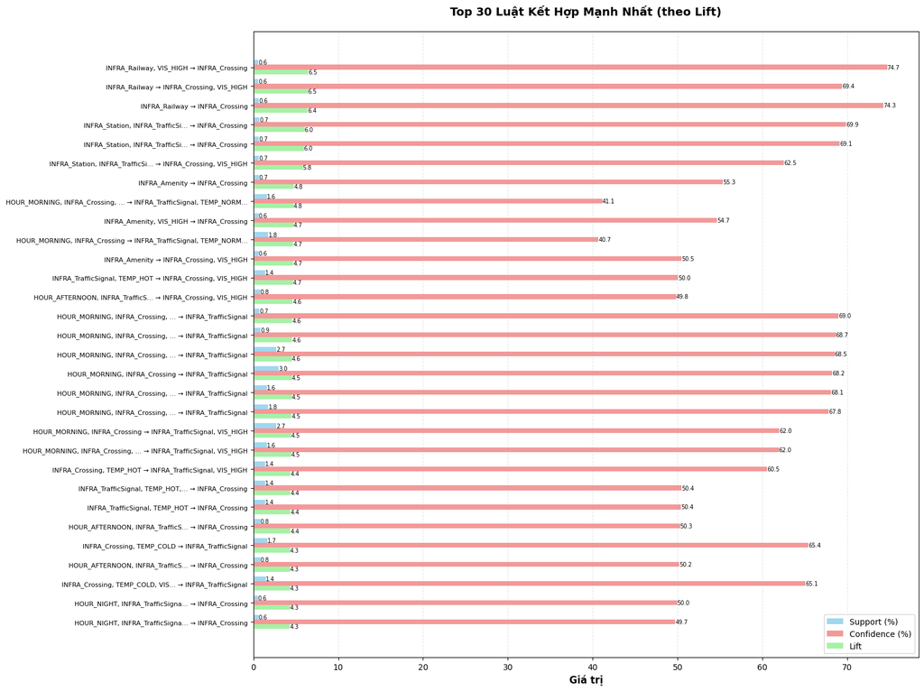

```python
fig, ax = plt.subplots(figsize=(16, 12))

# Lấy top 30 luật
top_30 = rules_filtered.head(30).copy()

# Tạo labels cho trục y
y_labels = []
for idx, row in top_30.iterrows():
    antecedent = row['antecedents_str'][:30] + '...' if len(row['antecedents_str']) > 30 else row['antecedents_str']
    consequent = row['consequents_str'][:30] + '...' if len(row['consequents_str']) > 30 else row['consequents_str']
    y_labels.append(f"{antecedent} → {consequent}")

# Vẽ các metric
y_pos = np.arange(len(top_30))
width = 0.25

bars1 = ax.barh(y_pos - width, top_30['support']*100, width, label='Support (%)', alpha=0.8, color='skyblue')
bars2 = ax.barh(y_pos, top_30['confidence']*100, width, label='Confidence (%)', alpha=0.8, color='lightcoral')
bars3 = ax.barh(y_pos + width, top_30['lift'], width, label='Lift', alpha=0.8, color='lightgreen')

ax.set_yticks(y_pos)
ax.set_yticklabels(y_labels, fontsize=8)
ax.invert_yaxis()
ax.set_xlabel('Giá trị', fontsize=12, fontweight='bold')
ax.set_title('Top 30 Luật Kết Hợp Mạnh Nhất (theo Lift)', fontsize=14, fontweight='bold', pad=20)
ax.legend(loc='lower right', fontsize=10)
ax.grid(axis='x', alpha=0.3, linestyle='--')

# Thêm giá trị lên bars
for bars in [bars1, bars2, bars3]:
    for bar in bars:
        width_val = bar.get_width()
        if width_val > 0:
            ax.text(width_val, bar.get_y() + bar.get_height()/2,
                   f'{width_val:.1f}', ha='left', va='center', fontsize=7)

plt.tight_layout()
plt.savefig(output_dir / 'association_rules_table.png', dpi=300, bbox_inches='tight')
print("✓ Đã lưu: association_rules_table.png")
plt.show()
```

### 8.2. Network Graph - Mối quan hệ giữa các Items

```
✓ Đã lưu: association_network_graph.png
```

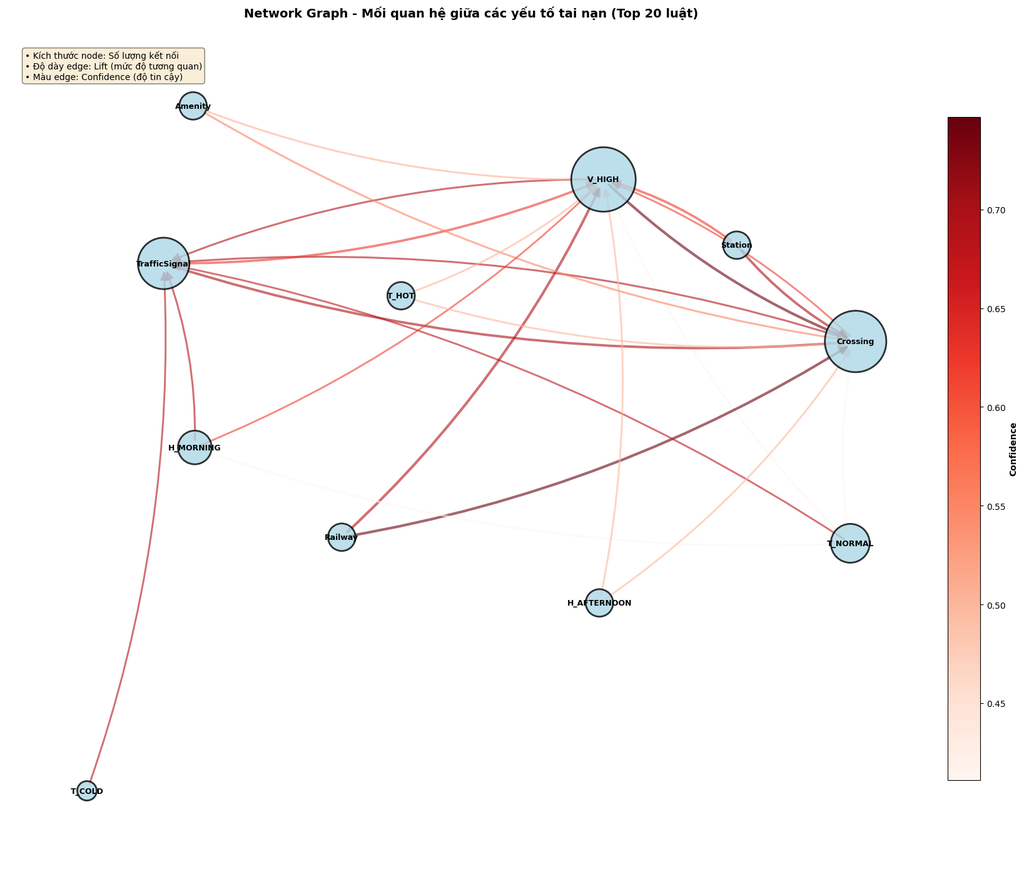

```python
fig, ax = plt.subplots(figsize=(18, 14))

# Lấy top 20 luật để vẽ network (tránh quá phức tạp)
top_rules_network = rules_filtered.head(20)

# Tạo directed graph
G = nx.DiGraph()

# Thêm edges từ antecedents đến consequents
for idx, row in top_rules_network.iterrows():
    for antecedent in row['antecedents']:
        for consequent in row['consequents']:
            # Thêm edge với weight là lift
            if G.has_edge(antecedent, consequent):
                # Nếu edge đã tồn tại, cập nhật weight bằng giá trị lớn hơn
                G[antecedent][consequent]['weight'] = max(G[antecedent][consequent]['weight'], row['lift'])
                G[antecedent][consequent]['confidence'] = max(G[antecedent][consequent]['confidence'], row['confidence'])
            else:
                G.add_edge(antecedent, consequent, weight=row['lift'], confidence=row['confidence'])

# Vẽ network
pos = nx.spring_layout(G, k=2, iterations=50, seed=42)

# Vẽ nodes
node_sizes = [G.degree(node) * 500 for node in G.nodes()]
nx.draw_networkx_nodes(G, pos, node_size=node_sizes, node_color='lightblue',
                       alpha=0.8, ax=ax, edgecolors='black', linewidths=2)

# Vẽ edges với độ dày theo lift
edges = G.edges()
weights = [G[u][v]['weight'] for u, v in edges]
confidences = [G[u][v]['confidence'] for u, v in edges]

# Normalize weights cho độ dày edge
max_weight = max(weights) if weights else 1
edge_widths = [3 * (w / max_weight) for w in weights]

# Vẽ edges với màu theo confidence
edge_colors = confidences
nx.draw_networkx_edges(G, pos, width=edge_widths, alpha=0.6,
                       edge_color=edge_colors, edge_cmap=plt.cm.Reds,
                       arrows=True, arrowsize=20, arrowstyle='-|>',
                       connectionstyle='arc3,rad=0.1', ax=ax)

# Vẽ labels
labels = {}
for node in G.nodes():
    # Rút gọn label nếu quá dài
    label = node.replace('INFRA_', '').replace('TEMP_', 'T_').replace('VIS_', 'V_').replace('HOUR_', 'H_')
    labels[node] = label

nx.draw_networkx_labels(G, pos, labels, font_size=9, font_weight='bold', ax=ax)

ax.set_title('Network Graph - Mối quan hệ giữa các yếu tố tai nạn (Top 20 luật)',
             fontsize=14, fontweight='bold', pad=20)
ax.axis('off')

# Thêm colorbar cho edge colors
sm = plt.cm.ScalarMappable(cmap=plt.cm.Reds, norm=plt.Normalize(vmin=min(confidences), vmax=max(confidences)))
sm.set_array([])
cbar = plt.colorbar(sm, ax=ax, orientation='vertical', pad=0.01, shrink=0.8)
cbar.set_label('Confidence', fontsize=10, fontweight='bold')

# Thêm chú thích
legend_text = "• Kích thước node: Số lượng kết nối\n• Độ dày edge: Lift (mức độ tương quan)\n• Màu edge: Confidence (độ tin cậy)"
ax.text(0.02, 0.98, legend_text, transform=ax.transAxes, fontsize=10,
        verticalalignment='top', bbox=dict(boxstyle='round', facecolor='wheat', alpha=0.5))

plt.tight_layout()
plt.savefig(output_dir / 'association_network_graph.png', dpi=300, bbox_inches='tight')
print("✓ Đã lưu: association_network_graph.png")
plt.show()
```

### 8.3. Support vs Confidence Scatter Plot (màu theo Lift)

```
✓ Đã lưu: association_support_confidence_scatter.png
```

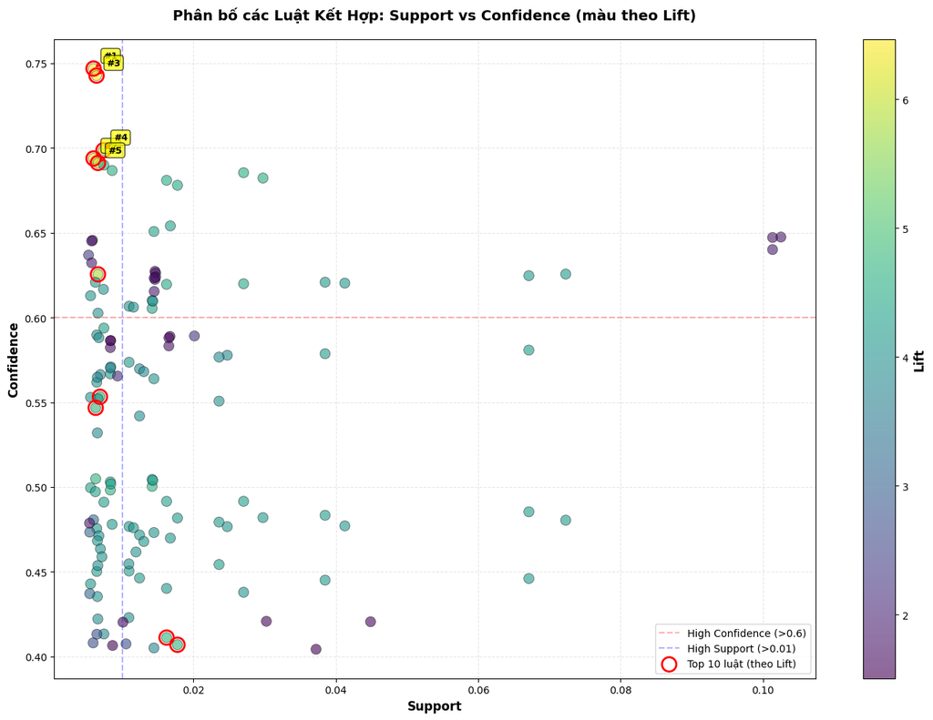

```python
fig, ax = plt.subplots(figsize=(14, 10))

# Vẽ scatter plot
scatter = ax.scatter(rules_filtered['support'],
                     rules_filtered['confidence'],
                     c=rules_filtered['lift'],
                     s=100,
                     alpha=0.6,
                     cmap='viridis',
                     edgecolors='black',
                     linewidths=0.5)

# Colorbar
cbar = plt.colorbar(scatter, ax=ax)
cbar.set_label('Lift', fontsize=12, fontweight='bold')

# Labels và title
ax.set_xlabel('Support', fontsize=12, fontweight='bold')
ax.set_ylabel('Confidence', fontsize=12, fontweight='bold')
ax.set_title('Phân bố các Luật Kết Hợp: Support vs Confidence (màu theo Lift)',
             fontsize=14, fontweight='bold', pad=20)

# Grid
ax.grid(True, alpha=0.3, linestyle='--')

# Thêm chú thích cho các vùng
ax.axhline(y=0.6, color='r', linestyle='--', alpha=0.3, label='High Confidence (>0.6)')
ax.axvline(x=0.01, color='b', linestyle='--', alpha=0.3, label='High Support (>0.01)')

# Đánh dấu top 10 luật
top_10 = rules_filtered.head(10)
ax.scatter(top_10['support'], top_10['confidence'],
           s=200, facecolors='none', edgecolors='red', linewidths=2,
           label='Top 10 luật (theo Lift)')

# Annotate top 5
for idx, row in rules_filtered.head(5).iterrows():
    ax.annotate(f"#{idx+1}",
                xy=(row['support'], row['confidence']),
                xytext=(10, 10),
                textcoords='offset points',
                fontsize=9,
                fontweight='bold',
                bbox=dict(boxstyle='round,pad=0.3', facecolor='yellow', alpha=0.7),
                arrowprops=dict(arrowstyle='->', connectionstyle='arc3,rad=0', color='red'))

ax.legend(loc='lower right', fontsize=10)

plt.tight_layout()
plt.savefig(output_dir / 'association_support_confidence_scatter.png', dpi=300, bbox_inches='tight')
print("✓ Đã lưu: association_support_confidence_scatter.png")
plt.show()
```

### 8.4. Tần suất xuất hiện của các Items trong các Luật

```
✓ Đã lưu: association_item_frequency.png
```

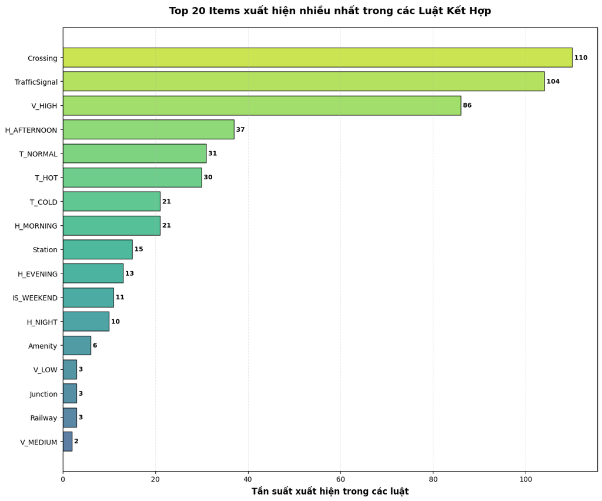

```
✓ Đã lưu tất cả 4 biểu đồ vào thư mục: figures\association
```

```python
# Đếm tần suất xuất hiện của mỗi item trong các luật (cả antecedents và consequents)
item_counts = {}

for idx, row in rules_filtered.iterrows():
    # Đếm từ antecedents
    for item in row['antecedents']:
        item_counts[item] = item_counts.get(item, 0) + 1
    # Đếm từ consequents
    for item in row['consequents']:
        item_counts[item] = item_counts.get(item, 0) + 1

# Chuyển thành DataFrame và sắp xếp
item_freq_df = pd.DataFrame(list(item_counts.items()), columns=['Item', 'Frequency'])
item_freq_df = item_freq_df.sort_values('Frequency', ascending=True)

# Lấy top 20
top_items = item_freq_df.tail(20)

# Vẽ biểu đồ
fig, ax = plt.subplots(figsize=(12, 10))

# Tạo màu gradient
colors = plt.cm.viridis(np.linspace(0.3, 0.9, len(top_items)))

bars = ax.barh(range(len(top_items)), top_items['Frequency'], color=colors, alpha=0.8, edgecolor='black')

# Rút gọn tên items
labels = [item.replace('INFRA_', '').replace('TEMP_', 'T_').replace('VIS_', 'V_').replace('HOUR_', 'H_')
          for item in top_items['Item']]

ax.set_yticks(range(len(top_items)))
ax.set_yticklabels(labels, fontsize=10)
ax.set_xlabel('Tần suất xuất hiện trong các luật', fontsize=12, fontweight='bold')
ax.set_title('Top 20 Items xuất hiện nhiều nhất trong các Luật Kết Hợp',
             fontsize=14, fontweight='bold', pad=20)
ax.grid(axis='x', alpha=0.3, linestyle='--')

# Thêm giá trị lên bars
for i, (bar, freq) in enumerate(zip(bars, top_items['Frequency'])):
    ax.text(freq, i, f' {freq}', va='center', ha='left', fontsize=9, fontweight='bold')

plt.tight_layout()
plt.savefig(output_dir / 'association_item_frequency.png', dpi=300, bbox_inches='tight')
print("✓ Đã lưu: association_item_frequency.png")
plt.show()

print(f"\n✓ Đã lưu tất cả 4 biểu đồ vào thư mục: {output_dir}")
```

## 9. Phân tích và Diễn giải các Luật Kết Hợp Mạnh Nhất

Phân tích chi tiết các luật kết hợp có ý nghĩa thực tiễn cao nhất.

```python
print("="*100)
print("PHÂN TÍCH CHI TIẾT CÁC LUẬT KẾT HỢP MẠNH NHẤT")
print("="*100)

# Phân tích theo nhóm
print("\n" + "─"*100)
print("1. PHÂN TÍCH THEO THỜI GIAN")
print("─"*100)

# Lọc các luật liên quan đến thời gian
time_rules = rules_filtered[
    rules_filtered['antecedents_str'].str.contains('HOUR_') |
    rules_filtered['consequents_str'].str.contains('HOUR_')
].head(5)

if len(time_rules) > 0:
    for idx, row in time_rules.iterrows():
        print(f"\n✓ Luật: {row['antecedents_str']} → {row['consequents_str']}")
        print(f"  Support: {row['support']:.4f} | Confidence: {row['confidence']:.4f} | Lift: {row['lift']:.4f}")
        print(f"  Ý nghĩa: ", end="")

        if 'HOUR_MORNING' in row['antecedents_str'] or 'HOUR_MORNING' in row['consequents_str']:
            print("Tai nạn vào buổi sáng có mối liên hệ đặc biệt với các yếu tố khác.")
        elif 'HOUR_EVENING' in row['antecedents_str'] or 'HOUR_EVENING' in row['consequents_str']:
            print("Tai nạn vào buổi tối có đặc điểm riêng biệt.")
        elif 'HOUR_NIGHT' in row['antecedents_str'] or 'HOUR_NIGHT' in row['consequents_str']:
            print("Tai nạn vào ban đêm thường đi kèm với điều kiện khả năng quan sát kém.")
        else:
            print("Tai nạn vào buổi chiều có mẫu hình đặc trưng.")
else:
    print("Không tìm thấy luật nổi bật về thời gian.")

print("\n" + "─"*100)
print("2. PHÂN TÍCH THEO ĐIỀU KIỆN THỜI TIẾT")
print("─"*100)

# Lọc các luật liên quan đến thời tiết
weather_rules = rules_filtered[
    rules_filtered['antecedents_str'].str.contains('TEMP_|VIS_') |
    rules_filtered['consequents_str'].str.contains('TEMP_|VIS_')
].head(5)

if len(weather_rules) > 0:
    for idx, row in weather_rules.iterrows():
        print(f"\n✓ Luật: {row['antecedents_str']} → {row['consequents_str']}")
        print(f"  Support: {row['support']:.4f} | Confidence: {row['confidence']:.4f} | Lift: {row['lift']:.4f}")
        print(f"  Ý nghĩa: ", end="")

        if 'VIS_LOW' in row['antecedents_str'] or 'VIS_LOW' in row['consequents_str']:
            print("Tầm nhìn thấp có tương quan mạnh với các tai nạn nghiêm trọng.")
        elif 'TEMP_COLD' in row['antecedents_str'] or 'TEMP_COLD' in row['consequents_str']:
            print("Nhiệt độ lạnh tạo điều kiện thuận lợi cho tai nạn.")
        elif 'TEMP_HOT' in row['antecedents_str'] or 'TEMP_HOT' in row['consequents_str']:
            print("Nhiệt độ cao cũng ảnh hưởng đến nguy cơ tai nạn.")
        else:
            print("Điều kiện thời tiết ảnh hưởng đến mẫu hình tai nạn.")
else:
    print("Không tìm thấy luật nổi bật về thời tiết.")

print("\n" + "─"*100)
print("3. PHÂN TÍCH THEO CƠ SỞ HẠ TẦNG")
print("─"*100)

# Lọc các luật liên quan đến infrastructure
infra_rules = rules_filtered[
    rules_filtered['antecedents_str'].str.contains('INFRA_') |
    rules_filtered['consequents_str'].str.contains('INFRA_')
].head(5)

if len(infra_rules) > 0:
    for idx, row in infra_rules.iterrows():
        print(f"\n✓ Luật: {row['antecedents_str']} → {row['consequents_str']}")
        print(f"  Support: {row['support']:.4f} | Confidence: {row['confidence']:.4f} | Lift: {row['lift']:.4f}")
        print(f"  Ý nghĩa: ", end="")

        if 'INFRA_TrafficSignal' in row['antecedents_str'] or 'INFRA_TrafficSignal' in row['consequents_str']:
            print("Đèn giao thông là yếu tố quan trọng trong các tai nạn đô thị.")
        elif 'INFRA_Crossing' in row['antecedents_str'] or 'INFRA_Crossing' in row['consequents_str']:
            print("Vị trí băng qua đường có nguy cơ tai nạn cao.")
        elif 'INFRA_Junction' in row['antecedents_str'] or 'INFRA_Junction' in row['consequents_str']:
            print("Giao lộ là điểm nóng về tai nạn giao thông.")
        elif 'INFRA_Stop' in row['antecedents_str'] or 'INFRA_Stop' in row['consequents_str']:
            print("Biển báo dừng có mối liên hệ với các tai nạn đặc thủ.")
        else:
            print("Yếu tố cơ sở hạ tầng ảnh hưởng đến tai nạn.")
else:
    print("Không tìm thấy luật nổi bật về cơ sở hạ tầng.")

print("\n" + "─"*100)
print("4. PHÂN TÍCH CUỐI TUẦN")
print("─"*100)

# Lọc các luật liên quan đến weekend
weekend_rules = rules_filtered[
    rules_filtered['antecedents_str'].str.contains('IS_WEEKEND') |
    rules_filtered['consequents_str'].str.contains('IS_WEEKEND')
].head(3)

if len(weekend_rules) > 0:
    for idx, row in weekend_rules.iterrows():
        print(f"\n✓ Luật: {row['antecedents_str']} → {row['consequents_str']}")
        print(f"  Support: {row['support']:.4f} | Confidence: {row['confidence']:.4f} | Lift: {row['lift']:.4f}")
        print(f"  Ý nghĩa: Tai nạn cuối tuần có mẫu hình khác biệt so với ngày thường.")
else:
    print("Không tìm thấy luật nổi bật về cuối tuần.")

print("\n" + "="*100)
```

```
====================================================================================================
PHÂN TÍCH CHI TIẾT CÁC LUẬT KẾT HỢP MẠNH NHẤT
====================================================================================================

────────────────────────────────────────────────────────────────────────────────────────────────────
1. PHÂN TÍCH THEO THỜI GIAN
────────────────────────────────────────────────────────────────────────────────────────────────────

✓ Luật: HOUR_MORNING, INFRA_Crossing, VIS_HIGH → INFRA_TrafficSignal, TEMP_NORMAL
  Support: 0.0162 | Confidence: 0.4112 | Lift: 4.7538
  Ý nghĩa: Tai nạn vào buổi sáng có mối liên hệ đặc biệt với các yếu tố khác.

✓ Luật: HOUR_MORNING, INFRA_Crossing → INFRA_TrafficSignal, TEMP_NORMAL
  Support: 0.0177 | Confidence: 0.4069 | Lift: 4.7049
  Ý nghĩa: Tai nạn vào buổi sáng có mối liên hệ đặc biệt với các yếu tố khác.

✓ Luật: HOUR_AFTERNOON, INFRA_TrafficSignal, TEMP_HOT → INFRA_Crossing, VIS_HIGH
  Support: 0.0083 | Confidence: 0.4982 | Lift: 4.6366
  Ý nghĩa: Tai nạn vào buổi chiều có mẫu hình đặc trưng.

✓ Luật: HOUR_MORNING, INFRA_Crossing, TEMP_COLD, VIS_HIGH → INFRA_TrafficSignal
  Support: 0.0074 | Confidence: 0.6899 | Lift: 4.5843
  Ý nghĩa: Tai nạn vào buổi sáng có mối liên hệ đặc biệt với các yếu tố khác.

✓ Luật: HOUR_MORNING, INFRA_Crossing, TEMP_COLD → INFRA_TrafficSignal
  Support: 0.0086 | Confidence: 0.6867 | Lift: 4.5628
  Ý nghĩa: Tai nạn vào buổi sáng có mối liên hệ đặc biệt với các yếu tố khác.

────────────────────────────────────────────────────────────────────────────────────────────────────
2. PHÂN TÍCH THEO ĐIỀU KIỆN THỜI TIẾT
────────────────────────────────────────────────────────────────────────────────────────────────────

✓ Luật: INFRA_Railway, VIS_HIGH → INFRA_Crossing
  Support: 0.0060 | Confidence: 0.7469 | Lift: 6.4625
  Ý nghĩa: Điều kiện thời tiết ảnh hưởng đến mẫu hình tai nạn.

✓ Luật: INFRA_Railway → INFRA_Crossing, VIS_HIGH
  Support: 0.0060 | Confidence: 0.6938 | Lift: 6.4572
  Ý nghĩa: Điều kiện thời tiết ảnh hưởng đến mẫu hình tai nạn.

```

[output cut: 38 more lines]

```
────────────────────────────────────────────────────────────────────────────────────────────────────

✓ Luật: INFRA_TrafficSignal, IS_WEEKEND, VIS_HIGH → INFRA_Crossing
  Support: 0.0065 | Confidence: 0.4683 | Lift: 4.0521
  Ý nghĩa: Tai nạn cuối tuần có mẫu hình khác biệt so với ngày thường.

✓ Luật: INFRA_TrafficSignal, IS_WEEKEND → INFRA_Crossing, VIS_HIGH
  Support: 0.0065 | Confidence: 0.4354 | Lift: 4.0518
  Ý nghĩa: Tai nạn cuối tuần có mẫu hình khác biệt so với ngày thường.

✓ Luật: INFRA_TrafficSignal, IS_WEEKEND → INFRA_Crossing
  Support: 0.0069 | Confidence: 0.4635 | Lift: 4.0105
  Ý nghĩa: Tai nạn cuối tuần có mẫu hình khác biệt so với ngày thường.

====================================================================================================
```

## 10. Kết luận và Ứng dụng Thực tiễn

### Tóm tắt kết quả:

Đã áp dụng thành công thuật toán **FP-Growth** để khám phá các luật kết hợp từ dữ liệu tai nạn giao thông, tìm ra các mối liên hệ "nếu-thì" có ý nghĩa giữa các yếu tố gây tai nạn.

### Ứng dụng thực tiễn:

1. **Quy hoạch Giao thông**:
   - Ưu tiên cải thiện cơ sở hạ tầng tại các vị trí có sự kết hợp nguy hiểm của nhiều yếu tố
   - Lắp đặt thêm đèn chiếu sáng tại các khu vực có tầm nhìn thấp
   - Tăng cường biển báo cảnh báo tại các điểm có nhiều yếu tố nguy hiểm kết hợp
2. **Dự báo và Cảnh báo**:
   - Phát triển hệ thống cảnh báo dựa trên sự kết hợp của các yếu tố
   - Cảnh báo đặc biệt khi có sự kết hợp của thời tiết xấu + thời gian nguy hiểm + cơ sở hạ tầng thiếu an toàn
   - Tăng cường tuần tra tại các điểm có luật kết hợp với lift cao
3. **Giáo dục An toàn**:
   - Tuyên truyền về các tổ hợp yếu tố nguy hiểm cụ thể
   - Hướng dẫn lái xe cách xử lý trong các tình huống kết hợp nhiều yếu tố rủi ro
   - Nâng cao nhận thức về các điểm đen tai nạn có đặc điểm riêng
4. **Chính sách Quản lý**:
   - Phân bổ nguồn lực dựa trên độ ưu tiên của các luật kết hợp
   - Thiết kế các biện pháp can thiệp nhắm vào các tổ hợp yếu tố cụ thể
   - Đánh giá hiệu quả của các biện pháp an toàn giao thông

### Hạn chế và Hướng phát triển:

1. **Hạn chế**:
   - Dữ liệu chỉ phản ánh mối tương quan, không chứng minh quan hệ nhân quả
   - Một số luật có support thấp có thể không đáng tin cậy cho ứng dụng rộng rãi
   - Chất lượng dữ liệu gốc ảnh hưởng đến độ chính xác của các luật
2. **Hướng phát triển**:
   - Kết hợp thêm dữ liệu về mật độ giao thông, loại xe, điều kiện đường
   - Áp dụng các thuật toán khác như Apriori, ECLAT để so sánh kết quả
   - Phân tích theo vùng địa lý cụ thể để tìm các luật địa phương
   - Tích hợp với các mô hình Machine Learning khác để dự đoán tai nạn

## 11. Xuất kết quả ra file CSV

```python
# Xuất frequent itemsets
itemsets_output = frequent_itemsets.copy()
itemsets_output['itemsets_str'] = itemsets_output['itemsets'].apply(lambda x: ', '.join(sorted(x)))
itemsets_output = itemsets_output[['itemsets_str', 'support', 'length']].sort_values('support', ascending=False)
itemsets_output.to_csv(output_dir / 'frequent_itemsets.csv', index=False, encoding='utf-8-sig')

print(f"✓ Đã xuất {len(itemsets_output):,} frequent itemsets ra file: frequent_itemsets.csv")

# Xuất association rules
rules_output = rules_filtered[['antecedents_str', 'consequents_str', 'support', 'confidence', 'lift']].copy()
rules_output.columns = ['Antecedents', 'Consequents', 'Support', 'Confidence', 'Lift']
rules_output.to_csv(output_dir / 'association_rules.csv', index=False, encoding='utf-8-sig')

print(f"✓ Đã xuất {len(rules_output):,} association rules ra file: association_rules.csv")

# Xuất item frequency
item_freq_df.to_csv(output_dir / 'item_frequency.csv', index=False, encoding='utf-8-sig')

print(f"✓ Đã xuất {len(item_freq_df):,} item frequencies ra file: item_frequency.csv")

print(f"\n{'='*80}")
print("HOÀN THÀNH PHÂN TÍCH ASSOCIATION RULES VỚI FP-GROWTH!")
print(f"{'='*80}")
print(f"✓ Số lượng giao dịch phân tích: {len(df_binary):,}")
print(f"✓ Số lượng features: {len(df_binary.columns)}")
print(f"✓ Số lượng frequent itemsets: {len(frequent_itemsets):,}")
print(f"✓ Số lượng association rules: {len(rules_filtered):,}")
print(f"✓ Đã lưu 4 biểu đồ và 3 file CSV vào: {output_dir}")
print(f"{'='*80}")
```

```
✓ Đã xuất 286 frequent itemsets ra file: frequent_itemsets.csv
✓ Đã xuất 137 association rules ra file: association_rules.csv
✓ Đã xuất 17 item frequencies ra file: item_frequency.csv

================================================================================
HOÀN THÀNH PHÂN TÍCH ASSOCIATION RULES VỚI FP-GROWTH!
================================================================================
✓ Số lượng giao dịch phân tích: 100,000
✓ Số lượng features: 24
✓ Số lượng frequent itemsets: 286
✓ Số lượng association rules: 137
✓ Đã lưu 4 biểu đồ và 3 file CSV vào: figures\association
================================================================================
```